# Hackathon_Starter

Sri Seshadri

6/26/2019

# 1.0 Congratulations you made it here! Thank you for being here!

## 1.1 Objective :

1. We will be attempting to forecast bike rentals in DC metro area for the period 12/1/2012 to 12/31/2012
2. We will use the data in Train.csv to analyze the data and build a predictive/forecasting model.
3. Forecast the “cnt” variable for the next 31 days and report it in Result.csv, by filling in the second column in Resut.csv.
4. Browse Readme.txt to get familiar with the data dictionary.
5. If you are using R as your tool for this exercise, you are welcome to use this file as your starter code.

# 2.0 Package requirements

1. tidyverse
2. forecast
3. lubridate
4. xts
5. car*
6. magrittr
7. purrr*
8. plotly*
9. lattice
10. skimr*
11. astsa*

The ones marked with asterix are optional.

```r
#*****************************************
#         Libraries used
#*****************************************
library(magrittr)
library(tidyverse)
library(forecast)
library(astsa)
library(plotly)
library(lattice)
library(xts)
library(lubridate)
library(purrr)
```

# 3.0 Read data

```r
bike <-  read.csv('Train.csv',stringsAsFactors = F)

# inspect data
skimr::skim(bike)
```

```
## Skim summary statistics
##  n obs: 700
##  n variables: 16
##
## -- Variable type:character --------------------------------------------------------------------------------------------------------------
##  variable missing complete   n min max empty n_unique
##    dteday       0      700 700   8  10     0      700
##
## -- Variable type:integer ----------------------------------------------------------------------------------------------------------------
##    variable missing complete   n     mean      sd p0     p25    p50
##      casual       0      700 700  866.82   693.96  2  317     737
##         cnt       0      700 700 4527.09  1940.99 22 3193    4540
##     holiday       0      700 700    0.029    0.17  0    0       0
##     instant       0      700 700  350.5    202.22  1  175.75  350.5
##        mnth       0      700 700    6.28     3.32  1    3       6
##  registered       0      700 700 3660.28  1554.42 20 2506.75 3651.5
##      season       0      700 700    2.48     1.09  1    2       2
##  weathersit       0      700 700    1.38     0.54  1    1       1
##     weekday       0      700 700    3        2     0    1       3
##  workingday       0      700 700    0.69     0.46  0    0       1
##          yr       0      700 700    0.48     0.5   0    0       0
##      p75 p100     hist
##  1135.75 3410 ▇▇▅▂▁▁▁▁
##  6041.5  8714 ▁▅▅▇▇▅▆▂
##     0       1 ▇▁▁▁▁▁▁▁
##   525.25  700 ▇▇▇▇▇▇▇▇
##     9      12 ▇▅▇▃▅▇▅▆
##  4740.75 6946 ▁▅▅▆▇▅▃▃
##     3       4 ▇▁▇▁▁▇▁▇
##     2       3 ▇▁▁▅▁▁▁▁
##     5       6 ▇▇▇▇▁▇▇▇
##     1       1 ▃▁▁▁▁▁▁▇
##     1       1 ▇▁▁▁▁▁▁▇
##
## -- Variable type:numeric ----------------------------------------------------------------------------------------------------------------
##   variable missing complete   n mean    sd    p0  p25  p50  p75 p100
##      atemp       0      700 700 0.48 0.16  0.079 0.35 0.5  0.61 0.84
##        hum       0      700 700 0.63 0.14  0     0.52 0.62 0.73 0.97
##       temp       0      700 700 0.5  0.18  0.059 0.34 0.51 0.66 0.86
##  windspeed       0      700 700 0.19 0.077 0.022 0.14 0.18 0.23 0.51
##      hist
##  ▁▃▆▆▇▇▆▁
##  ▁▁▁▃▇▇▅▂
##  ▁▃▇▇▆▇▇▃
##  ▂▆▇▆▂▁▁▁
```

## 3.1 Change data types

```r
# changing categorical variables into factors.
# The symbol %<>%  takes the variable to the left of it, modifies it based on whats on the right of it and saves it back in the same variable. As in ... a = a + 5

bike %<>%
  mutate(dteday = as.Date(dteday,format = "%m/%d/%Y")) %>%
  mutate(season = as.factor(season),
         weathersit = as.factor(weathersit),
         weekday = as.factor(weekday),
         holiday = as.factor(holiday),
         mnth = as.factor(mnth),
         workingday = as.factor(workingday),
         season = as.factor(season),
         yr = as.factor(yr)
         )

str(bike)
```

```
## 'data.frame':    700 obs. of  16 variables:
##  $ instant   : int  1 2 3 4 5 6 7 8 9 10 ...
##  $ dteday    : Date, format: "2011-01-01" "2011-01-02" ...
##  $ season    : Factor w/ 4 levels "1","2","3","4": 1 1 1 1 1 1 1 1 1 1 ...
##  $ yr        : Factor w/ 2 levels "0","1": 1 1 1 1 1 1 1 1 1 1 ...
##  $ mnth      : Factor w/ 12 levels "1","2","3","4",..: 1 1 1 1 1 1 1 1 1 1 ...
##  $ holiday   : Factor w/ 2 levels "0","1": 1 1 1 1 1 1 1 1 1 1 ...
##  $ weekday   : Factor w/ 7 levels "0","1","2","3",..: 7 1 2 3 4 5 6 7 1 2 ...
##  $ workingday: Factor w/ 2 levels "0","1": 1 1 2 2 2 2 2 1 1 2 ...
##  $ weathersit: Factor w/ 3 levels "1","2","3": 2 2 1 1 1 1 2 2 1 1 ...
##  $ temp      : num  0.344 0.363 0.196 0.2 0.227 ...
##  $ atemp     : num  0.364 0.354 0.189 0.212 0.229 ...
##  $ hum       : num  0.806 0.696 0.437 0.59 0.437 ...
##  $ windspeed : num  0.16 0.249 0.248 0.16 0.187 ...
##  $ casual    : int  331 131 120 108 82 88 148 68 54 41 ...
##  $ registered: int  654 670 1229 1454 1518 1518 1362 891 768 1280 ...
##  $ cnt       : int  985 801 1349 1562 1600 1606 1510 959 822 1321 ...
```

```r
bikexts <- xts(bike,order.by = bike$dteday)


#**************************************************************
#             Function to make time series objects
#**************************************************************

makets <- function(dataframe,start, frequency = 365.25){

  # we have not used a for loop, but elegantly applied a function to every column in the data frame, using the purrr library

  library(purrr)

  1:ncol(dataframe) %>%
    map(function(x) ts(dataframe[,x],start = start, frequency = frequency))
}

bike %>%
  select(-instant) %>%
  select_if(is.numeric) %>% colnames() -> tsnames

bike %>%
  select(-instant) %>%
  select_if(is.numeric) %>%
  makets(., start = bike$dteday[1]) -> tslist

names(tslist) <- tsnames

# Explore other series by choosing other variables for example tslist$temp
tslist$cnt
```

```
## Time Series:
## Start = 14975
## End = 14976.9137577002
## Frequency = 365.25
##   [1]  985  801 1349 1562 1600 1606 1510  959  822 1321 1263 1162 1406 1421
##  [15] 1248 1204 1000  683 1650 1927 1543  981  986 1416 1985  506  431 1167
##  [29] 1098 1096 1501 1360 1526 1550 1708 1005 1623 1712 1530 1605 1538 1746
##  [43] 1472 1589 1913 1815 2115 2475 2927 1635 1812 1107 1450 1917 1807 1461
##  [57] 1969 2402 1446 1851 2134 1685 1944 2077  605 1872 2133 1891  623 1977
##  [71] 2132 2417 2046 2056 2192 2744 3239 3117 2471 2077 2703 2121 1865 2210
##  [85] 2496 1693 2028 2425 1536 1685 2227 2252 3249 3115 1795 2808 3141 1471
##  [99] 2455 2895 3348 2034 2162 3267 3126  795 3744 3429 3204 3944 4189 1683
## [113] 4036 4191 4073 4400 3872 4058 4595 5312 3351 4401 4451 2633 4433 4608
## [127] 4714 4333 4362 4803 4182 4864 4105 3409 4553 3958 4123 3855 4575 4917
## [141] 5805 4660 4274 4492 4978 4677 4679 4758 4788 4098 3982 3974 4968 5312
```

[output cut: 39 more lines]

# 4.0 Exploratory Data Analysis

What would you do in Power BI, how would you explore the data? Something to that effect…

Below is an example

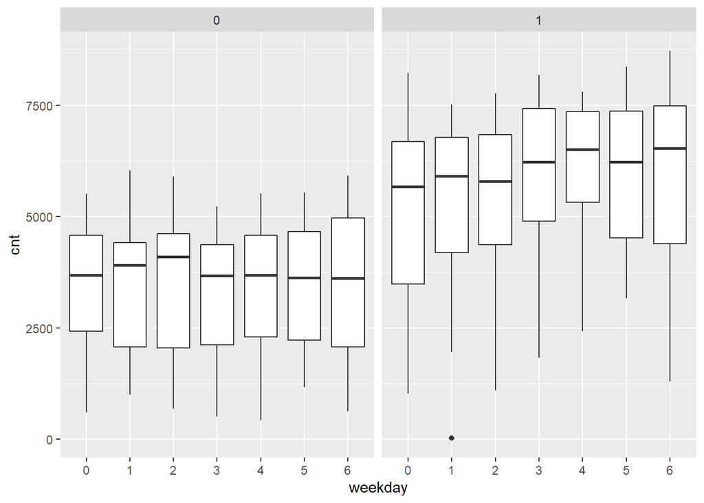

```r
bike %>%
  ggplot(aes(x=weekday, y = cnt)) + geom_boxplot() + facet_wrap(~yr)
```

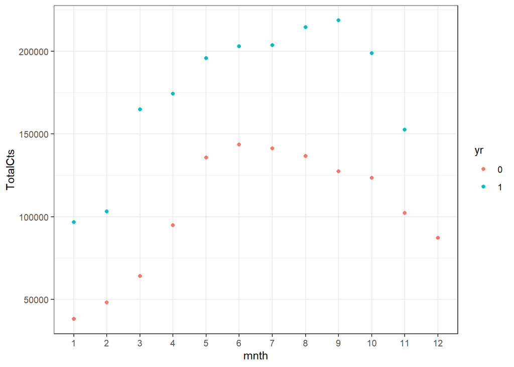

```r
bike %>%
  group_by(yr,mnth) %>%
  summarise(TotalCts = sum(cnt)) %>%
  ggplot(aes(x=mnth, y = TotalCts, col = yr)) + geom_point() + theme_bw()
```

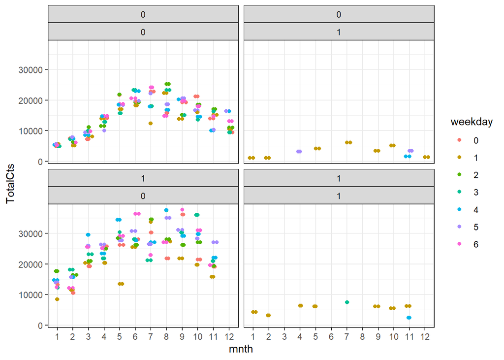

```r
bike %>%
  group_by(yr,mnth,weekday,holiday) %>%
  summarise(TotalCts = sum(cnt)) %>%
  ggplot(aes(x=mnth, y = TotalCts, col = weekday)) + geom_point() + geom_jitter(width = 0.25) + theme_bw() + facet_wrap(~yr + holiday,ncol = 2)
```

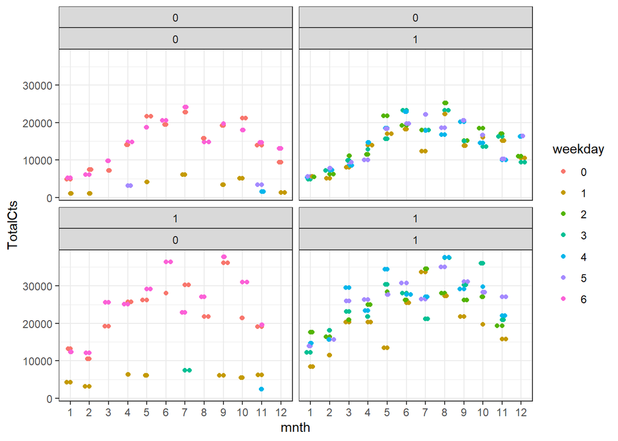

```r
bike %>%
  group_by(yr,mnth,weekday,workingday) %>%
  summarise(TotalCts = sum(cnt)) %>%
  ggplot(aes(x=mnth, y = TotalCts, col = weekday)) + geom_point() + geom_jitter(width = 0.25) + theme_bw() + facet_wrap(~yr + workingday,ncol = 2)
```

Successful model building comes after good exploration of the data, visualize data to see what are useful columns in predicting cnts…what is correlated with what?

# 5.0 Modeling

## 5.1 Splitting data into training and validation

```r
# if you want to split the data into training and validation ... like earmark the last 30 days of the data to make it your validation data for model evaluation... then here is how you can do it

training <- bike[1:670,]
validation <-  bike[671:700,]

trainingxts <- xts(training%>%
  select(-instant) %>%
  select_if(is.numeric),order.by = training$dteday)

validationxts <- xts(validation%>%
  select(-instant) %>%
  select_if(is.numeric),order.by = validation$dteday)

traintslist <-  training %>%
  select(-instant) %>%
  select_if(is.numeric) %>%
  makets(., start = training$dteday[1])

names(traintslist) <- tsnames

validationtslist <-  validation %>%
  select(-instant) %>%
  select_if(is.numeric) %>%
  makets(., start = validation$dteday[1])

names(validationtslist) <- tsnames
```

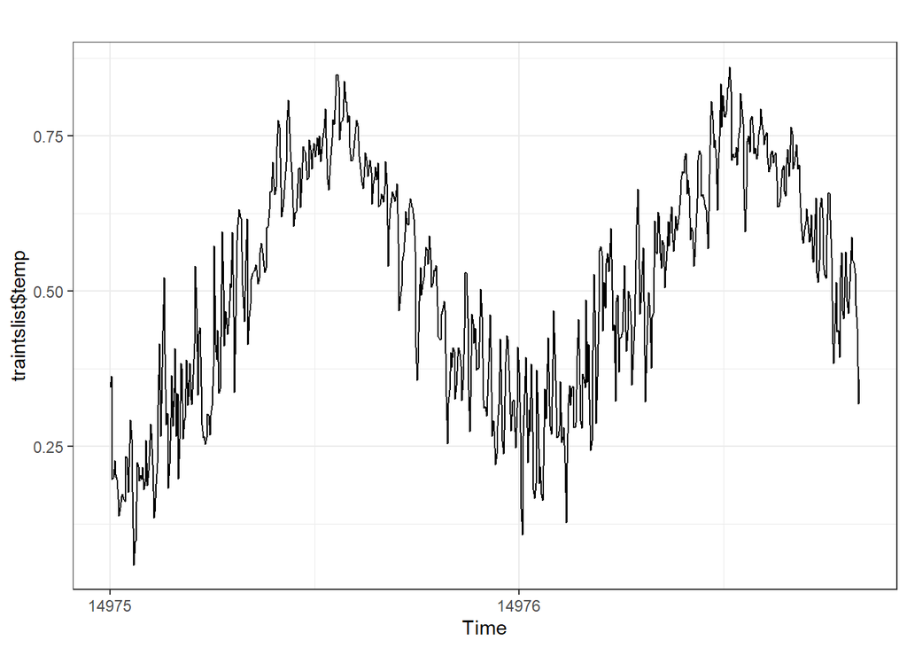

```r
# Sampler for using the time series lists
autoplot(traintslist$temp) + theme_bw()
```

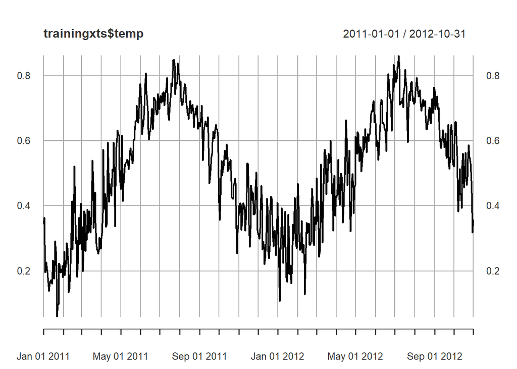

```r
plot(trainingxts$temp)
```

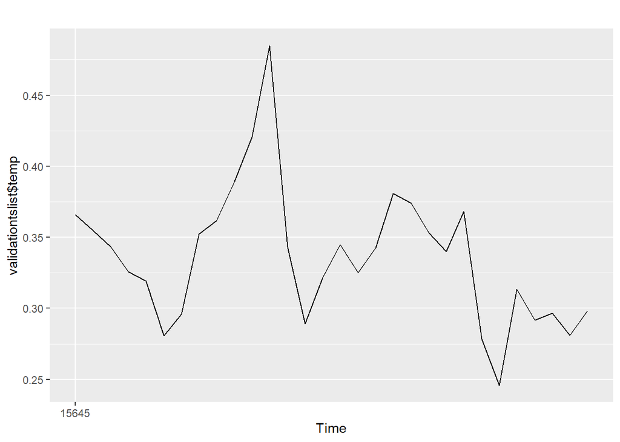

```r
autoplot(validationtslist$temp)
```

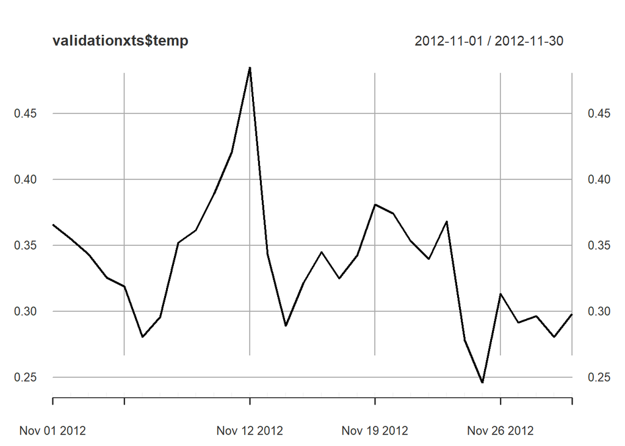

```r
plot(validationxts$temp)
```

## 5.2 Thoughts on modeling

1. Try model “cnts” directly - naive, ETS, ARIMA and others
2. Leverage other variables in the data set.
3. Be mindful of relationship between and among columns in the data.
4. Try things we did with the housing sales data.